# Notebook

Set figure to display inside notebook

```python
%matplotlib inline
```

Import library to use

```python
import numpy as np
from pandas import *
import pandas as pd
import matplotlib.pyplot as plt
from matplotlib import *
import matplotlib.pylab as pylab
pylab.rcParams['figure.figsize'] = 12, 8  # change default size of figures
```

Reading input to pandas

```python
dtresult = pd.read_csv('/home/wgmn4901/dtanalysis.csv', delimiter=' ', header=None)
```

```python
dtdata = dtresult[range(1,21)]
dtindex = dtresult[0]
#dtcolumns=['thread1','thread2','thread3','thread4','thread5','thread6','thread7','thread8',
#         'thread9','thread10','thread11','thread12','thread13','thread14','thread15','thread16',
#         'thread17','thread18','thread19','thread20']
dtdata.index = dtindex.str.replace('T1|T2|T3|T4|T5', '',case=False)
# dtdata.columns = dtcolumns
```

From this point we will only working on data of one host. **We can select the host here**. The tests performed on the 5 servers are the same. So the figures for one host is enough, otherwise it would be redundant. I intended to use the results on other servers for a *reference* of our results. From these data, I'm thinking we can develop some kind of factor that represents the interference on the cluster. Kind of *"similarity coefficience"*. If the similarity (from the result) between the 5 servers is little, then we have too much interference or the figure from one server cannot be a representative. But if similarity is high, then we can conclude that we don't have much interefence that affects on our study.

```python
hostbf1 = range(1,5)
hostbf2 = range(5,9)
hostbf3 = range(9,13)
hostbf4 = range(13,17)
hostbf5 = range(17,21)

selectedhost = hostbf1 # Changing host by defining range (1,5)=bf1, (5,9)=bf2, (9,13)=bf3, (13,17)=bf4, (17,21)=bf5

onehostdata = dtdata[selectedhost]
```

```python
# To calculate the average throughput, we first calculate average throughput each thread has in one test, then again take the
# average of 5 tests
avgtpin1test = onehostdata.T.mean() # Average throughput of each thread/VM in one test
avgtpin5tests = avgtpin1test.groupby(level=0).mean() # Average throughput of each thread/VM in 5 tests
avgtpin5tests = avgtpin5tests / 1024 # Converting to Megabytes/second
```

```python
# Putting average throughput per thread/VM to vector before plotting
bwsrbf = avgtpin5tests.filter(regex="^SRBFTH").tolist()
bwswbf = avgtpin5tests.filter(regex="^SWBFTH").tolist()
bwrrbf = avgtpin5tests.filter(regex="^RRBFTH").tolist()
bwrwbf = avgtpin5tests.filter(regex="^RWBFTH").tolist()
bwsrsvm = avgtpin5tests.filter(regex="^SR1VMTH").tolist()
bwswsvm = avgtpin5tests.filter(regex="^SW1VMTH").tolist()
bwrrsvm = avgtpin5tests.filter(regex="^RR1VMTH").tolist()
bwrwsvm = avgtpin5tests.filter(regex="^RW1VMTH").tolist()
bwsrmvm = avgtpin5tests.filter(regex="^SR[1-4]VMTH1").tolist()
bwswmvm = avgtpin5tests.filter(regex="^SW[1-4]VMTH1").tolist()
bwrrmvm = avgtpin5tests.filter(regex="^RR[1-4]VMTH1").tolist()
bwrwmvm = avgtpin5tests.filter(regex="^RW[1-4]VMTH1").tolist()
```

```python
# Calculate aggregated throughput on each host of each test, then taking the average
aggtpin1test = onehostdata.T.sum() # Aggregate throughput on each host in one test
avgaggtpin5tests = aggtpin1test.groupby(level=0).mean() # Then calculate the average of the total throughput through 5 tests
avgaggtpin5tests = avgaggtpin5tests / 1024
```

```python
# Putting average aggregate throughput to vector before plotting
aggbwsrbf = avgaggtpin5tests.filter(regex="^SRBFTH").tolist()
aggbwswbf = avgaggtpin5tests.filter(regex="^SWBFTH").tolist()
aggbwrrbf = avgaggtpin5tests.filter(regex="^RRBFTH").tolist()
aggbwrwbf = avgaggtpin5tests.filter(regex="^RWBFTH").tolist()
aggbwsrsvm = avgaggtpin5tests.filter(regex="^SR1VMTH").tolist()
aggbwswsvm = avgaggtpin5tests.filter(regex="^SW1VMTH").tolist()
aggbwrrsvm = avgaggtpin5tests.filter(regex="^RR1VMTH").tolist()
aggbwrwsvm = avgaggtpin5tests.filter(regex="^RW1VMTH").tolist()
aggbwsrmvm = avgaggtpin5tests.filter(regex="^SR[1-4]VMTH1").tolist()
aggbwswmvm = avgaggtpin5tests.filter(regex="^SW[1-4]VMTH1").tolist()
aggbwrrmvm = avgaggtpin5tests.filter(regex="^RR[1-4]VMTH1").tolist()
aggbwrwmvm = avgaggtpin5tests.filter(regex="^RW[1-4]VMTH1").tolist()
```

## Throughput

Plotting throughput for 4 different IO access patterns: sequential read, sequential write, random read, random write

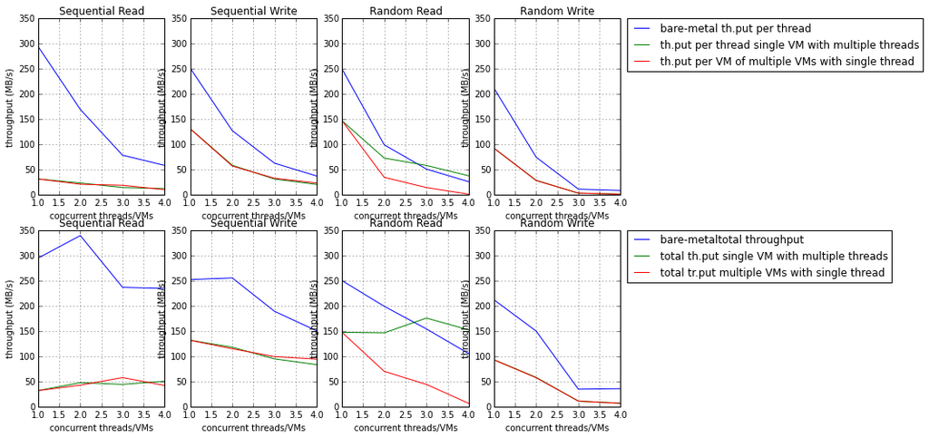

```python
x_axis = [1,2,3,4]

plt.subplot(241)
plt.plot(x_axis, bwsrbf, x_axis, bwsrsvm, x_axis, bwsrmvm)
plt.axis([1, 4, 0, 350])
plt.grid(True)
plt.title('Sequential Read')
pylab.xlabel('concurrent threads/VMs')
pylab.ylabel('throughput (MB/s)')

plt.subplot(242)
plt.plot(x_axis, bwswbf, x_axis, bwswsvm, x_axis, bwswmvm)
plt.axis([1, 4, 0, 350])
plt.grid(True)
plt.title('Sequential Write')
pylab.xlabel('concurrent threads/VMs')
pylab.ylabel('throughput (MB/s)')

plt.subplot(243)
plt.plot(x_axis, bwrrbf, x_axis, bwrrsvm, x_axis, bwrrmvm)
plt.axis([1, 4, 0, 350])
plt.grid(True)
plt.title('Random Read')
pylab.xlabel('concurrent threads/VMs')
pylab.ylabel('throughput (MB/s)')

plt.subplot(244)
plt.plot(x_axis, bwrwbf, label = 'bare-metal th.put per thread')
plt.plot(x_axis, bwrwsvm, label = 'th.put per thread single VM with multiple threads')
plt.plot(x_axis, bwrwmvm, label = 'th.put per VM of multiple VMs with single thread')
plt.axis([1, 4, 0, 350])
plt.grid(True)
plt.title('Random Write')
plt.legend(bbox_to_anchor=(1.05, 1), loc=2, borderaxespad=0.)
pylab.xlabel('concurrent threads/VMs')
pylab.ylabel('throughput (MB/s)')

plt.subplot(245)
plt.plot(x_axis, aggbwsrbf, x_axis, aggbwsrsvm, x_axis, aggbwsrmvm)
plt.axis([1, 4, 0, 350])
plt.grid(True)
plt.title('Sequential Read')
pylab.xlabel('concurrent threads/VMs')
pylab.ylabel('throughput (MB/s)')

plt.subplot(246)
plt.plot(x_axis, aggbwswbf, x_axis, aggbwswsvm, x_axis, aggbwswmvm)
plt.axis([1, 4, 0, 350])
plt.grid(True)
plt.title('Sequential Write')
pylab.xlabel('concurrent threads/VMs')
pylab.ylabel('throughput (MB/s)')

plt.subplot(247)
plt.plot(x_axis, aggbwrrbf, x_axis, aggbwrrsvm, x_axis, aggbwrrmvm)
plt.axis([1, 4, 0, 350])
plt.grid(True)
plt.title('Random Read')
pylab.xlabel('concurrent threads/VMs')
pylab.ylabel('throughput (MB/s)')

plt.subplot(248)
plt.plot(x_axis, aggbwrwbf, label = 'bare-metaltotal throughput')
plt.plot(x_axis, aggbwrwsvm, label = 'total th.put single VM with multiple threads')
plt.plot(x_axis, aggbwrwmvm, label = 'total tr.put multiple VMs with single thread')
plt.axis([1, 4, 0, 350])
plt.grid(True)
plt.title('Random Write')
plt.legend(bbox_to_anchor=(1.05, 1), loc=2, borderaxespad=0.)
pylab.xlabel('concurrent threads/VMs')
pylab.ylabel('throughput (MB/s)')
```

The storage review suggest that our hard drives having peak speed at 115 MB/s for sequenctial read/write and 57 MB/s for random read/write with the test of 4K block size. However, we got triple the rate!?!?!? This transfer rate is like a modern Solid State Drive (SSD), not an hard drive with only 7200rpm.

http://www.storagereview.com/seagate_constellation2_and_constellation_es2_hard_drive_review

One explanation for this maybe because of the IO depth that they are using. When we run the same test with I/O depth at 1 for with native asynchonous I/O library of Linux, we also got around this value. Or maythe program that we use got a bug when reporting.

## Throughput normalization

*(throughput of bare-metal is used as baseline)*

```python
from __future__ import division # floating point division in Py2x
# for throughput per thread/VM
nml_bwsrbf = [x/y for x,y in zip(bwsrbf,bwsrbf)]
nml_bwswbf = [x/y for x,y in zip(bwswbf,bwswbf)]
nml_bwrrbf = [x/y for x,y in zip(bwrrbf,bwrrbf)]
nml_bwrwbf = [x/y for x,y in zip(bwrwbf,bwrwbf)]
nml_bwsrsvm = [x/y for x,y in zip(bwsrsvm,bwsrbf)]
nml_bwswsvm = [x/y for x,y in zip(bwswsvm,bwswbf)]
nml_bwrrsvm = [x/y for x,y in zip(bwrrsvm,bwrrbf)]
nml_bwrwsvm = [x/y for x,y in zip(bwrwsvm,bwrwbf)]
nml_bwsrmvm = [x/y for x,y in zip(bwsrmvm,bwsrbf)]
nml_bwswmvm = [x/y for x,y in zip(bwswmvm,bwswbf)]
nml_bwrrmvm = [x/y for x,y in zip(bwrrmvm,bwrrbf)]
nml_bwrwmvm = [x/y for x,y in zip(bwrwmvm,bwrwbf)]
# for aggregated throughput
nml_aggbwsrbf = [x/y for x,y in zip(aggbwsrbf,aggbwsrbf)]
nml_aggbwswbf = [x/y for x,y in zip(aggbwswbf,aggbwswbf)]
nml_aggbwrrbf = [x/y for x,y in zip(aggbwrrbf,aggbwrrbf)]
nml_aggbwrwbf = [x/y for x,y in zip(aggbwrwbf,aggbwrwbf)]
nml_aggbwsrsvm = [x/y for x,y in zip(aggbwsrsvm,aggbwsrbf)]
nml_aggbwswsvm = [x/y for x,y in zip(aggbwswsvm,aggbwswbf)]
nml_aggbwrrsvm = [x/y for x,y in zip(aggbwrrsvm,aggbwrrbf)]
nml_aggbwrwsvm = [x/y for x,y in zip(aggbwrwsvm,aggbwrwbf)]
nml_aggbwsrmvm = [x/y for x,y in zip(aggbwsrmvm,aggbwsrbf)]
nml_aggbwswmvm = [x/y for x,y in zip(aggbwswmvm,aggbwswbf)]
nml_aggbwrrmvm = [x/y for x,y in zip(aggbwrrmvm,aggbwrrbf)]
nml_aggbwrwmvm = [x/y for x,y in zip(aggbwrwmvm,aggbwrwbf)]

# Normilization figures look the same, so this is to check the calculation
print bwsrsvm
print bwsrbf
print nml_bwsrsvm
print aggbwsrsvm
print aggbwsrbf
print nml_aggbwsrsvm
```

```
[31.652734375000001, 23.70654296875, 14.668684895833334, 12.558886718749999]
[294.6416015625, 169.69287109375, 78.869466145833329, 58.586572265625001]
[0.10742791991064356, 0.13970264523164841, 0.18598686681497564, 0.21436459299597532]
[31.652734375000001, 47.4130859375, 44.006054687499997, 50.235546874999997]
[294.6416015625, 339.3857421875, 236.6083984375, 234.34628906250001]
[0.10742791991064356, 0.13970264523164841, 0.18598686681497562, 0.21436459299597532]
```

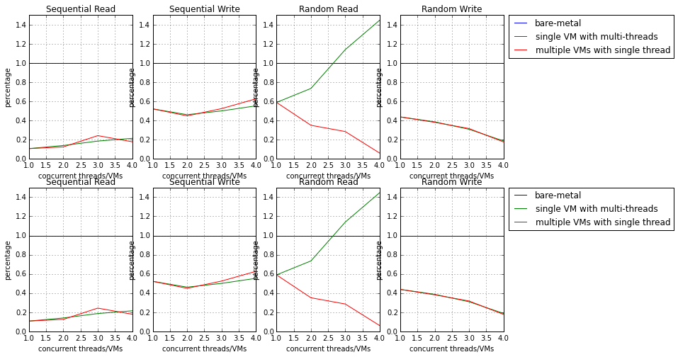

```python
x_axis = [1,2,3,4]

plt.subplot(241)
plt.plot(x_axis, nml_bwsrbf, x_axis, nml_bwsrsvm, x_axis, nml_bwsrmvm)
plt.axis([1, 4, 0, 1.5])
plt.grid(True)
plt.title('Sequential Read')
pylab.xlabel('concurrent threads/VMs')
pylab.ylabel('percentage')

plt.subplot(242)
plt.plot(x_axis, nml_bwswbf, x_axis, nml_bwswsvm, x_axis, nml_bwswmvm)
plt.axis([1, 4, 0, 1.5])
plt.grid(True)
plt.title('Sequential Write')
pylab.xlabel('concurrent threads/VMs')
pylab.ylabel('percentage')

plt.subplot(243)
plt.plot(x_axis, nml_bwrrbf, x_axis, nml_bwrrsvm, x_axis, nml_bwrrmvm)
plt.axis([1, 4, 0, 1.5])
plt.grid(True)
plt.title('Random Read')
pylab.xlabel('concurrent threads/VMs')
pylab.ylabel('percentage')

plt.subplot(244)
plt.plot(x_axis, nml_bwrwbf, label = 'bare-metal')
plt.plot(x_axis, nml_bwrwsvm, label = 'single VM with multi-threads')
plt.plot(x_axis, nml_bwrwmvm, label = 'multiple VMs with single thread')
plt.axis([1, 4, 0, 1.5])
plt.grid(True)
plt.title('Random Write')
plt.legend(bbox_to_anchor=(1.05, 1), loc=2, borderaxespad=0.)
pylab.xlabel('concurrent threads/VMs')
pylab.ylabel('percentage')

plt.subplot(245)
plt.plot(x_axis, nml_aggbwsrbf, x_axis, nml_aggbwsrsvm, x_axis, nml_aggbwsrmvm)
plt.axis([1, 4, 0, 1.5])
plt.grid(True)
plt.title('Sequential Read')
pylab.xlabel('concurrent threads/VMs')
pylab.ylabel('percentage')

plt.subplot(246)
plt.plot(x_axis, nml_aggbwswbf, x_axis, nml_aggbwswsvm, x_axis, nml_aggbwswmvm)
plt.axis([1, 4, 0, 1.5])
plt.grid(True)
plt.title('Sequential Write')
pylab.xlabel('concurrent threads/VMs')
pylab.ylabel('percentage')

plt.subplot(247)
plt.plot(x_axis, nml_aggbwrrbf, x_axis, nml_aggbwrrsvm, x_axis, nml_aggbwrrmvm)
plt.axis([1, 4, 0, 1.5])
plt.grid(True)
plt.title('Random Read')
pylab.xlabel('concurrent threads/VMs')
pylab.ylabel('percentage')

plt.subplot(248)
plt.plot(x_axis, nml_aggbwrwbf, label = 'bare-metal')
plt.plot(x_axis, nml_aggbwrwsvm, label = 'single VM with multi-threads')
plt.plot(x_axis, nml_aggbwrwmvm, label = 'multiple VMs with single thread')
plt.axis([1, 4, 0, 1.5])
plt.grid(True)
plt.title('Random Write')
plt.legend(bbox_to_anchor=(1.05, 1), loc=2, borderaxespad=0.)
pylab.xlabel('concurrent threads/VMs')
pylab.ylabel('percentage')
```

## Jain Fairness Index

```python
jfidataofhost = dtdata[selectedhost] # Use only data on 1 host, changing host by redefining range
jfi = jfidataofhost.T.sum()**2/jfidataofhost.T.count()/(jfidataofhost**2).T.sum() #Calculate Jair Fairness Index for each test
jfiavg = jfi.groupby(level=0).mean() # Calculate JFI average from 5 tests
jfistd = jfi.groupby(level=0).std() # Standard Deviation

jfisrbf = jfiavg.filter(regex="^SRBFTH").tolist()
jfiswbf = jfiavg.filter(regex="^SWBFTH").tolist()
jfirrbf = jfiavg.filter(regex="^RRBFTH").tolist()
jfirwbf = jfiavg.filter(regex="^RWBFTH").tolist()
jfisrsvm = jfiavg.filter(regex="^SR1VMTH").tolist()
jfiswsvm = jfiavg.filter(regex="^SW1VMTH").tolist()
jfirrsvm = jfiavg.filter(regex="^RR1VMTH").tolist()
jfirwsvm = jfiavg.filter(regex="^RW1VMTH").tolist()
jfisrmvm = jfiavg.filter(regex="^SR[1-4]VMTH1").tolist()
jfiswmvm = jfiavg.filter(regex="^SW[1-4]VMTH1").tolist()
jfirrmvm = jfiavg.filter(regex="^RR[1-4]VMTH1").tolist()
jfirwmvm = jfiavg.filter(regex="^RW[1-4]VMTH1").tolist()
```

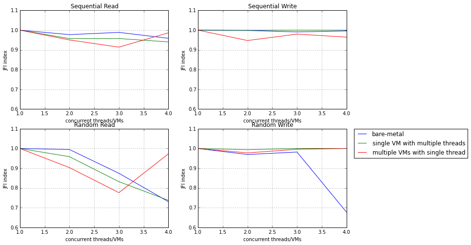

```python
x_axis = [1,2,3,4]

plt.subplot(221)
plt.plot(x_axis, jfisrbf, x_axis, jfisrsvm, x_axis, jfisrmvm)
plt.axis([1, 4, 0.6, 1.1])
plt.grid(True)
plt.title('Sequential Read')
pylab.xlabel('concurrent threads/VMs')
pylab.ylabel('JFI index')

plt.subplot(222)
plt.plot(x_axis, jfiswbf, x_axis, jfiswsvm, x_axis, jfiswmvm)
plt.axis([1, 4, 0.6, 1.1])
plt.grid(True)
plt.title('Sequential Write')
pylab.xlabel('concurrent threads/VMs')
pylab.ylabel('JFI index')

plt.subplot(223)
plt.plot(x_axis, jfirrbf, x_axis, jfirrsvm, x_axis, jfirrmvm)
plt.axis([1, 4, 0.6, 1.1])
plt.grid(True)
plt.title('Random Read')
pylab.xlabel('concurrent threads/VMs')
pylab.ylabel('JFI index')

plt.subplot(224)
plt.plot(x_axis, jfirwbf, label = 'bare-metal')
plt.plot(x_axis, jfirwsvm, label = 'single VM with multiple threads')
plt.plot(x_axis, jfirwmvm, label = 'multiple VMs with single thread')
plt.axis([1, 4, 0.6, 1.1])
plt.grid(True)
plt.title('Random Write')
plt.legend(bbox_to_anchor=(1.05, 1), loc=2, borderaxespad=0.)
pylab.xlabel('concurrent threads/VMs')
pylab.ylabel('JFI index')
```

## CPU Utilization (User Space)

```python
# Remove percentage symbol in csv file first
!sed -i 's/%//g' /home/wgmn4901/dtCpuUsageUserSpace.csv
```

```python
cpuusresult = pd.read_csv('/home/wgmn4901/dtCpuUsageUserSpace.csv', delimiter=' ', header=None)
cpuusdata = cpuusresult[range(1,21)]
cpuusindex = cpuusresult[0]
cpuusdata.index = cpuusindex.str.replace('T1|T2|T3|T4|T5', '',case=False)
```

```python
cpuushostdata = cpuusdata[selectedhost]
cpuushostavgin1test = cpuushostdata.T.mean() # Mean of each thread/VM on 1 tests
cpuushostavgin5tests = cpuushostavgin1test.groupby(level=0).mean() # Mean of each thread/VM on 5 tests
```

```python
cpuussrbf = cpuushostavgin5tests.filter(regex="^SRBFTH").tolist()
cpuusswbf = cpuushostavgin5tests.filter(regex="^SWBFTH").tolist()
cpuusrrbf = cpuushostavgin5tests.filter(regex="^RRBFTH").tolist()
cpuusrwbf = cpuushostavgin5tests.filter(regex="^RWBFTH").tolist()
cpuussrsvm = cpuushostavgin5tests.filter(regex="^SR1VMTH").tolist()
cpuusswsvm = cpuushostavgin5tests.filter(regex="^SW1VMTH").tolist()
cpuusrrsvm = cpuushostavgin5tests.filter(regex="^RR1VMTH").tolist()
cpuusrwsvm = cpuushostavgin5tests.filter(regex="^RW1VMTH").tolist()
cpuussrmvm = cpuushostavgin5tests.filter(regex="^SR[1-4]VMTH1").tolist()
cpuusswmvm = cpuushostavgin5tests.filter(regex="^SW[1-4]VMTH1").tolist()
cpuusrrmvm = cpuushostavgin5tests.filter(regex="^RR[1-4]VMTH1").tolist()
cpuusrwmvm = cpuushostavgin5tests.filter(regex="^RW[1-4]VMTH1").tolist()
```

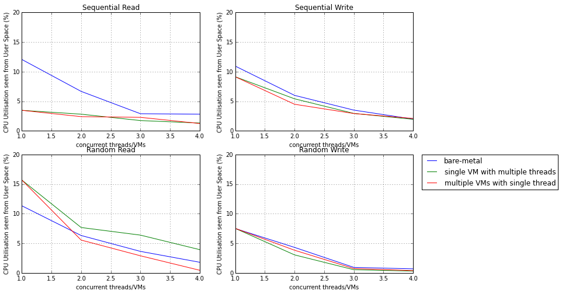

```python
x_axis = [1,2,3,4]

plt.subplot(221)
plt.plot(x_axis, cpuussrbf, x_axis, cpuussrsvm, x_axis, cpuussrmvm)
plt.axis([1, 4, 0, 20])
plt.grid(True)
plt.title('Sequential Read')
pylab.xlabel('concurrent threads/VMs')
pylab.ylabel('CPU Utilisation seen from User Space (%)')

plt.subplot(222)
plt.plot(x_axis, cpuusswbf, x_axis, cpuusswsvm, x_axis, cpuusswmvm)
plt.axis([1, 4, 0, 20])
plt.grid(True)
plt.title('Sequential Write')
pylab.xlabel('concurrent threads/VMs')
pylab.ylabel('CPU Utilisation seen from User Space (%)')

plt.subplot(223)
plt.plot(x_axis, cpuusrrbf, x_axis, cpuusrrsvm, x_axis, cpuusrrmvm)
plt.axis([1, 4, 0, 20])
plt.grid(True)
plt.title('Random Read')
pylab.xlabel('concurrent threads/VMs')
pylab.ylabel('CPU Utilisation seen from User Space (%)')

plt.subplot(224)
plt.plot(x_axis, cpuusrwbf, label = 'bare-metal')
plt.plot(x_axis, cpuusrwsvm, label = 'single VM with multiple threads')
plt.plot(x_axis, cpuusrwmvm, label = 'multiple VMs with single thread')
plt.axis([1, 4, 0, 20])
plt.grid(True)
plt.title('Random Write')
plt.legend(bbox_to_anchor=(1.05, 1), loc=2, borderaxespad=0.)
pylab.xlabel('concurrent threads/VMs')
pylab.ylabel('CPU Utilisation seen from User Space (%)')
```

## CPU Utilisation (Kernel Space)

```python
# Remove percentage symbol in csv file first
!sed -i 's/%//g' /home/wgmn4901/dtCpuUsageSystemSpace.csv
```

```python
cpuksresult = pd.read_csv('/home/wgmn4901/dtCpuUsageSystemSpace.csv', delimiter=' ', header=None)
cpuksdata = cpuksresult[range(1,21)]
cpuksindex = cpuksresult[0]
cpuksdata.index = cpuksindex.str.replace('T1|T2|T3|T4|T5', '',case=False)
```

```python
cpukshostdata = cpuksdata[selectedhost]
cpukshostavgin1test = cpukshostdata.T.mean() # Mean of each thread/VM on 1 tests
cpukshostavgin5tests = cpukshostavgin1test.groupby(level=0).mean() # Mean of each thread/VM on 5 tests
```

```python
cpukssrbf = cpukshostavgin5tests.filter(regex="^SRBFTH").tolist()
cpuksswbf = cpukshostavgin5tests.filter(regex="^SWBFTH").tolist()
cpuksrrbf = cpukshostavgin5tests.filter(regex="^RRBFTH").tolist()
cpuksrwbf = cpukshostavgin5tests.filter(regex="^RWBFTH").tolist()
cpukssrsvm = cpukshostavgin5tests.filter(regex="^SR1VMTH").tolist()
cpuksswsvm = cpukshostavgin5tests.filter(regex="^SW1VMTH").tolist()
cpuksrrsvm = cpukshostavgin5tests.filter(regex="^RR1VMTH").tolist()
cpuksrwsvm = cpukshostavgin5tests.filter(regex="^RW1VMTH").tolist()
cpukssrmvm = cpukshostavgin5tests.filter(regex="^SR[1-4]VMTH1").tolist()
cpuksswmvm = cpukshostavgin5tests.filter(regex="^SW[1-4]VMTH1").tolist()
cpuksrrmvm = cpukshostavgin5tests.filter(regex="^RR[1-4]VMTH1").tolist()
cpuksrwmvm = cpukshostavgin5tests.filter(regex="^RW[1-4]VMTH1").tolist()
```

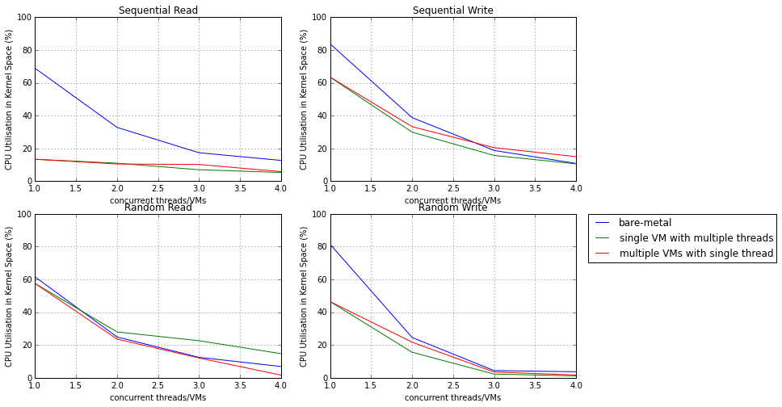

```python
x_axis = [1,2,3,4]

plt.subplot(221)
plt.plot(x_axis, cpukssrbf, x_axis, cpukssrsvm, x_axis, cpukssrmvm)
plt.axis([1, 4, 0, 100])
plt.grid(True)
plt.title('Sequential Read')
pylab.xlabel('concurrent threads/VMs')
pylab.ylabel('CPU Utilisation in Kernel Space (%)')

plt.subplot(222)
plt.plot(x_axis, cpuksswbf, x_axis, cpuksswsvm, x_axis, cpuksswmvm)
plt.axis([1, 4, 0, 100])
plt.grid(True)
plt.title('Sequential Write')
pylab.xlabel('concurrent threads/VMs')
pylab.ylabel('CPU Utilisation in Kernel Space (%)')

plt.subplot(223)
plt.plot(x_axis, cpuksrrbf, x_axis, cpuksrrsvm, x_axis, cpuksrrmvm)
plt.axis([1, 4, 0, 100])
plt.grid(True)
plt.title('Random Read')
pylab.xlabel('concurrent threads/VMs')
pylab.ylabel('CPU Utilisation in Kernel Space (%)')

plt.subplot(224)
plt.plot(x_axis, cpuksrwbf, label = 'bare-metal')
plt.plot(x_axis, cpuksrwsvm, label = 'single VM with multiple threads')
plt.plot(x_axis, cpuksrwmvm, label = 'multiple VMs with single thread')
plt.axis([1, 4, 0, 100])
plt.grid(True)
plt.title('Random Write')
plt.legend(bbox_to_anchor=(1.05, 1), loc=2, borderaxespad=0.)
pylab.xlabel('concurrent threads/VMs')
pylab.ylabel('CPU Utilisation in Kernel Space (%)')
```

## CPU utilisation in both spaces (per VM)

```python
cpusrbf = [x+y for x,y in zip(cpukssrbf, cpuussrbf)]
cpuswbf = [x+y for x,y in zip(cpuksswbf, cpuusswbf)]
cpurrbf = [x+y for x,y in zip(cpuksrrbf, cpuusrrbf)]
cpurwbf = [x+y for x,y in zip(cpuksrwbf, cpuusrwbf)]
cpusrsvm = [x+y for x,y in zip(cpukssrsvm, cpuussrsvm)]
cpuswsvm = [x+y for x,y in zip(cpuksswsvm, cpuusswsvm)]
cpurrsvm = [x+y for x,y in zip(cpuksrrsvm, cpuusrrsvm)]
cpurwsvm = [x+y for x,y in zip(cpuksrwsvm, cpuusrwsvm)]
cpusrmvm = [x+y for x,y in zip(cpukssrmvm, cpuussrmvm)]
cpuswmvm = [x+y for x,y in zip(cpuksswmvm, cpuusswmvm)]
cpurrmvm = [x+y for x,y in zip(cpuksrrmvm, cpuusrrmvm)]
cpurwmvm = [x+y for x,y in zip(cpuksrwmvm, cpuusrwmvm)]
```

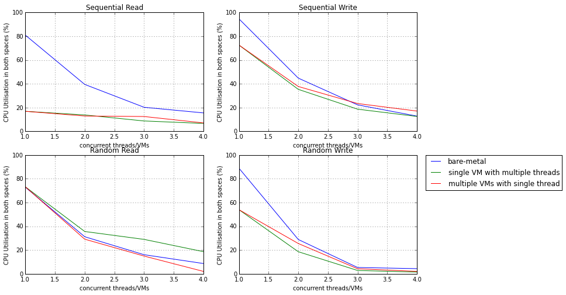

```python
x_axis = [1,2,3,4]

plt.subplot(221)
plt.plot(x_axis, cpusrbf)
plt.plot(x_axis, cpusrsvm)
plt.plot(x_axis, cpusrmvm)
plt.axis([1, 4, 0, 100])
plt.grid(True)
plt.title('Sequential Read')
pylab.xlabel('concurrent threads/VMs')
pylab.ylabel('CPU Utilisation in both spaces (%)')

plt.subplot(222)
plt.plot(x_axis, cpuswbf)
plt.plot(x_axis, cpuswsvm)
plt.plot(x_axis, cpuswmvm)
plt.axis([1, 4, 0, 100])
plt.grid(True)
plt.title('Sequential Write')
pylab.xlabel('concurrent threads/VMs')
pylab.ylabel('CPU Utilisation in both spaces (%)')

plt.subplot(223)
plt.plot(x_axis, cpurrbf)
plt.plot(x_axis, cpurrsvm)
plt.plot(x_axis, cpurrmvm)
plt.axis([1, 4, 0, 100])
plt.grid(True)
plt.title('Random Read')
pylab.xlabel('concurrent threads/VMs')
pylab.ylabel('CPU Utilisation in both spaces (%)')

plt.subplot(224)
plt.plot(x_axis, cpurwbf, label = 'bare-metal')
plt.plot(x_axis, cpurwsvm, label = 'single VM with multiple threads')
plt.plot(x_axis, cpurwmvm, label = 'multiple VMs with single thread')
plt.axis([1, 4, 0, 100])
plt.grid(True)
plt.title('Random Write')
plt.legend(bbox_to_anchor=(1.05, 1), loc=2, borderaxespad=0.)
pylab.xlabel('concurrent threads/VMs')
pylab.ylabel('CPU Utilisation in both spaces (%)')
```

## Context Switching

```python
cpucsresult = pd.read_csv('/home/wgmn4901/dtCpuUsageContextSwitch.csv', delimiter=' ', header=None)
cpucsdata = cpucsresult[range(1,21)]
cpucsindex = cpucsresult[0]
cpucsdata.index = cpucsindex.str.replace('T1|T2|T3|T4|T5', '',case=False)
```

```python
cpucshostdata = cpucsdata[selectedhost]
cpucshostavgin1test = cpucshostdata.T.mean() # Mean of CPU usage of each host in 1 test
cpucshostavgin5tests = cpucshostavgin1test.groupby(level=0).mean() # Mean of CPU usage of each host in 5 tests
```

```python
cpucssrbf = cpucshostavgin5tests.filter(regex="^SRBFTH").tolist()
cpucsswbf = cpucshostavgin5tests.filter(regex="^SWBFTH").tolist()
cpucsrrbf = cpucshostavgin5tests.filter(regex="^RRBFTH").tolist()
cpucsrwbf = cpucshostavgin5tests.filter(regex="^RWBFTH").tolist()
cpucssrsvm = cpucshostavgin5tests.filter(regex="^SR1VMTH").tolist()
cpucsswsvm = cpucshostavgin5tests.filter(regex="^SW1VMTH").tolist()
cpucsrrsvm = cpucshostavgin5tests.filter(regex="^RR1VMTH").tolist()
cpucsrwsvm = cpucshostavgin5tests.filter(regex="^RW1VMTH").tolist()
cpucssrmvm = cpucshostavgin5tests.filter(regex="^SR[1-4]VMTH1").tolist()
cpucsswmvm = cpucshostavgin5tests.filter(regex="^SW[1-4]VMTH1").tolist()
cpucsrrmvm = cpucshostavgin5tests.filter(regex="^RR[1-4]VMTH1").tolist()
cpucsrwmvm = cpucshostavgin5tests.filter(regex="^RW[1-4]VMTH1").tolist()
```

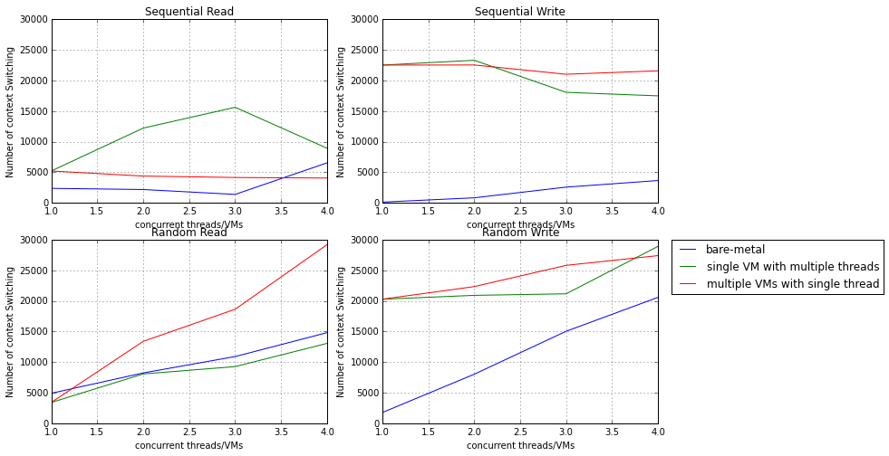

```python
x_axis = [1,2,3,4]

plt.subplot(221)
plt.plot(x_axis, cpucssrbf, x_axis, cpucssrsvm, x_axis, cpucssrmvm)
plt.axis([1, 4, 0, 30000])
plt.grid(True)
plt.title('Sequential Read')
pylab.xlabel('concurrent threads/VMs')
pylab.ylabel('Number of context Switching')

plt.subplot(222)
plt.plot(x_axis, cpucsswbf, x_axis, cpucsswsvm, x_axis, cpucsswmvm)
plt.axis([1, 4, 0, 30000])
plt.grid(True)
plt.title('Sequential Write')
pylab.xlabel('concurrent threads/VMs')
pylab.ylabel('Number of context Switching')

plt.subplot(223)
plt.plot(x_axis, cpucsrrbf, x_axis, cpucsrrsvm, x_axis, cpucsrrmvm)
plt.axis([1, 4, 0, 30000])
plt.grid(True)
plt.title('Random Read')
pylab.xlabel('concurrent threads/VMs')
pylab.ylabel('Number of context Switching')

plt.subplot(224)
plt.plot(x_axis, cpucsrwbf, label = 'bare-metal')
plt.plot(x_axis, cpucsrwsvm, label = 'single VM with multiple threads')
plt.plot(x_axis, cpucsrwmvm, label = 'multiple VMs with single thread')
plt.axis([1, 4, 0, 30000])
plt.grid(True)
plt.title('Random Write')
plt.legend(bbox_to_anchor=(1.05, 1), loc=2, borderaxespad=0.)
pylab.xlabel('concurrent threads/VMs')
pylab.ylabel('Number of context Switching')
```